# Prestige & Branding by Producers

Lauren Renaud

February, 2017

# Product names by quantity sold

Top 25 product names by quantity sold. This uses a combination of productname and producer name from the inventory transfers to estimate individual products created by specific producers.

*Some `productname`s and some `trans_name`s are NA (more concerned about `trans_name`). Need to review further.*

| Product Name | Producer Name | Quantity Sold |
| --- | --- | --- |
| Bulk Oil - Liberty Reach | BMF WASHINGTON | 22478 |
| CO2 Vaporizer Cartridge | AURICAG | 11576 |
| .5 gm Hybrid Cartridge | HARMONY FARMS | 9799 |
| 1g: Hydrocarbon Extract | AMBER BRICK | 8900 |
| EZ-Vape BHO | NORTHWEST CANNABIS SOLUTIONS | 8189 |
| Clear Cartridge | XTRACTED LABS | 5183 |
| WSU Crumble 1g | BLUE ROOTS CANNABIS | 4546 |
| Syringes | SILICA PHOENIX | 4292 |
| oil extract lots | GROW OP FARMS | 4199 |
| Cartridge - BHO Sativa Cartridge | NORTHWEST CANNABIS SOLUTIONS | 3929 |
| Oil/Cart/0.6g | THE MARKET GARDEN | 3888 |
| Bulk Oil - Jackpot Seaweed | BMF WASHINGTON | 3876 |
| Dab Wax: 1g - Tahoma | HONU ENTERPRISES | 3680 |
| The Clear Cartridge | XTRACTED LABS | 3646 |
| Rocket Man | NORTHWEST ORGANIC NURSERY | 3645 |
| Blueberry Shatter | AGRO COUTURE | 3326 |
| Snap and Pull 1g | COWLITZ COUNTY CANNABIS CULTIVATION | 3284 |
| Animal Cookies Shatter 1 Gram | PINGSTON CREEK BOTANICAL | 3271 |
| Wax 1g | COWLITZ COUNTY CANNABIS CULTIVATION | 3259 |
| Pineapple Cartridge 0.5g | TWO HEADS CO | 3219 |
| Blueberry Shatter 1.0 gram | AGRO COUTURE | 3179 |
| Oil/Cart/80-20/0.6g | THE MARKET GARDEN | 3049 |
| Shatter 1g | COWLITZ COUNTY CANNABIS CULTIVATION | 3028 |
| EZ-Vape CO2 | NORTHWEST CANNABIS SOLUTIONS | 2994 |
| Cotton Candy | KUSH VALLEY | 2948 |

# Distribution of price and quantity sold

Using the same combination of product name and producer name, this just looks at number sold and mean price for that product.

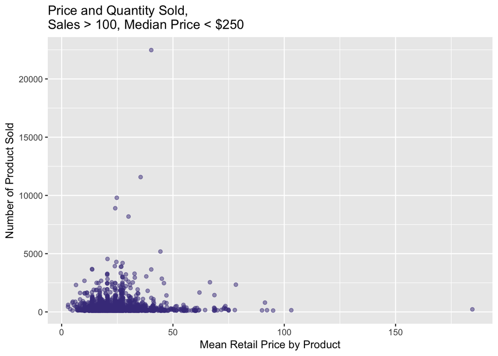

# Distribution of Prices by Producer

Looking at the mean, and median prices for a producer. This takes the mean for each product they sell, then takes the mean or median of those prices.

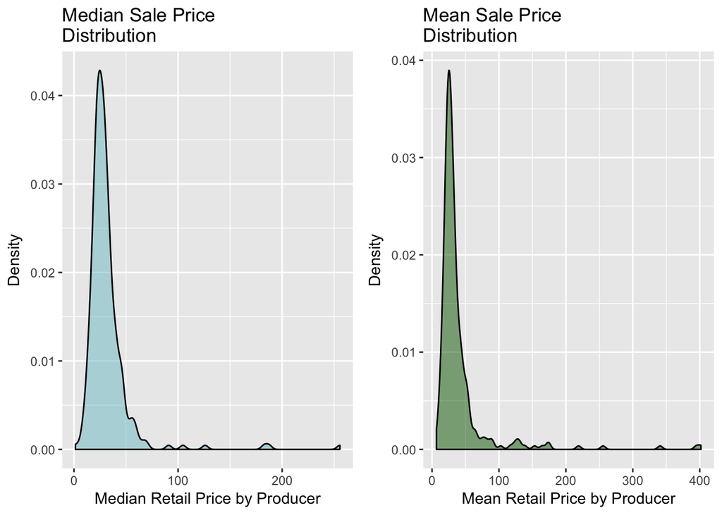

# Distribution of average price by products sold

We can also look at the relationship between mean or median price and number of products sold, but grouped on producer. This again finds the average price of each product, then finds the median price of products sold by a given producer to get their average price (x axis). Then finds the total number of items sold for a product, and takes median of that to get median products sold for each product that a producer creates.

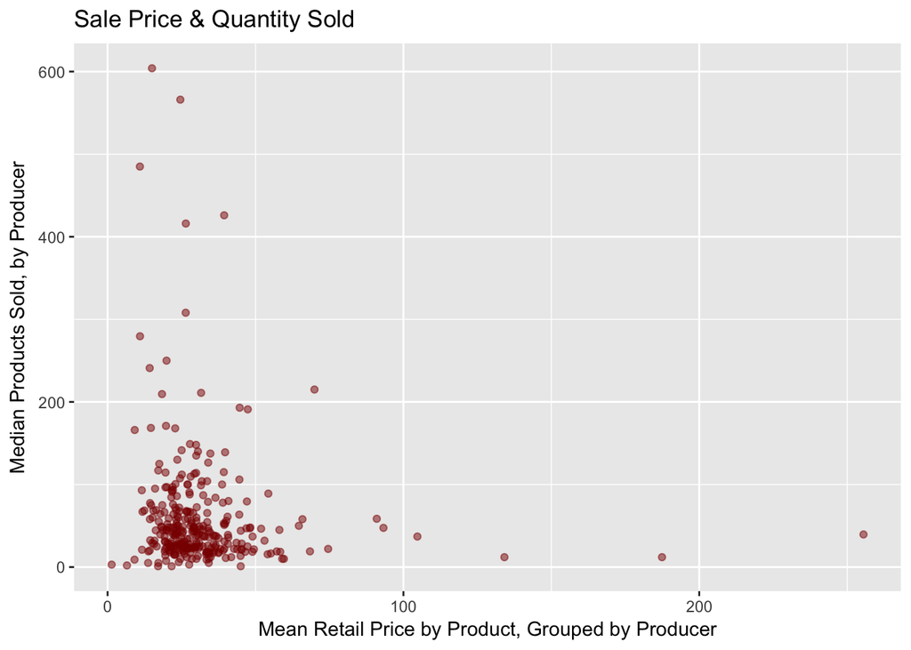

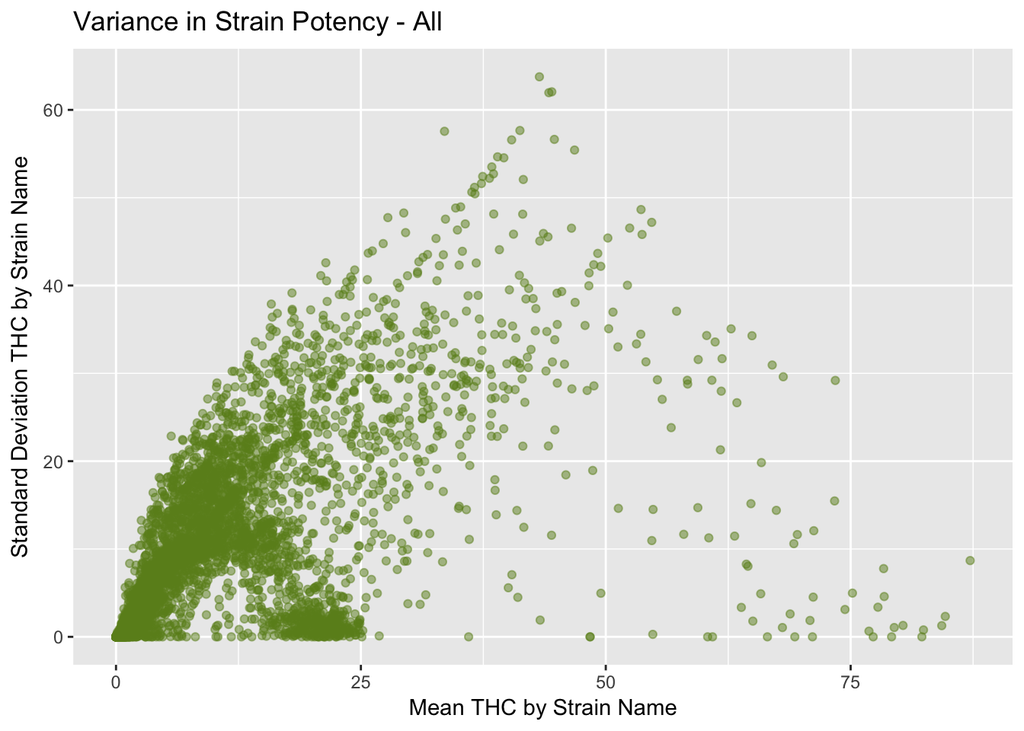

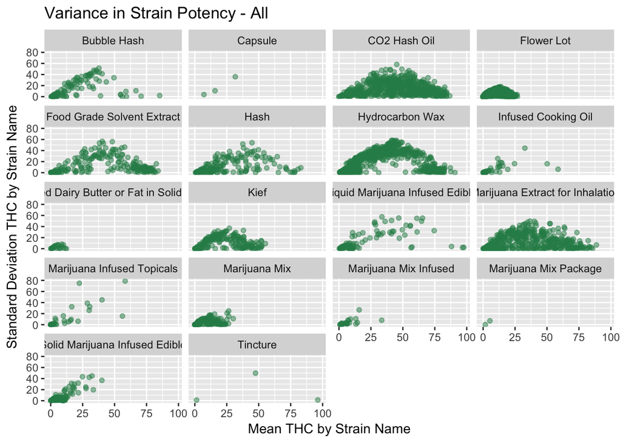